# Reproducibility Supplement

Prospective Validation of Multi-week Inpatient Census Forecasting for Pediatric HSCT and Cellular Therapy

Authors

Affiliations

Ezra Porter

Children’s Hospital of Philadelphia

Richard S Hanna

Children’s Hospital of Philadelphia

Timothy S Olson

Perelman School of Medicine, University of Pennsylvania

Stephan A Grupp

Children’s Hospital of Philadelphia

Charles A Phillips

Children’s Hospital of Philadelphia

Stephan Kadauke

Perelman School of Medicine, University of Pennsylvania

Published

July 10, 2026

# Introduction

This document provides computer code that was used to create the tables, figures, and results which we report in our manuscript, Prospective Validation of Multi-week Inpatient Census Forecasting for Pediatric HSCT and Cellular Therapy. We provide this document to allow other interested parties to inspect and verify our analytic work. Since the underlying data files contain extensive PHI, they are not publicly available and users will not be able to run this document themselves.

The first section lists concise descriptions of the steps performed in our Analyses. To view the code (written in the [R programming language](https://www.r-project.org/)) that was used to perform a specific step, as well as the results, click the black triangle to the left of the description to expand each section. The code relies heavily on the [`BMTCensusManuscript`](https://github.com/CHOP-CGTInformatics/BMTCensusManuscript) package developed to house code to reproduce the manuscript results. While the order of this section mirrors the order of results reported in the main manuscript, the section headings follow an analytical order laid out in the Materials and Methods section of the manuscript to allow greater depth in this document. Tables and figures from the main manuscript and supplementary materials are cross-referenced.

The second section describes the precise Computational Environment in which the computational analyses were performed. Among other parameters, this part lists the names, versions, and sources of all software packages that were used to generate this document.

# Analyses

## Setup

**Load required libraries**

```r
library(conflicted)

conflicts_prefer(dplyr::filter)

library(BMTCensusManuscript)
library(tidyverse)
library(timetk)
library(rsample)
library(parsnip)
library(workflows)
library(workflowsets)
library(modeltime)
library(modeltime.resample)
library(poissonreg)
library(parallel)
library(future)
library(dials)
library(recipes)
library(tune)
library(yardstick)
library(kableExtra)

theme_set(theme_minimal())
```

## Data

**Schematic overview of census prediction model **(Figure 1)**

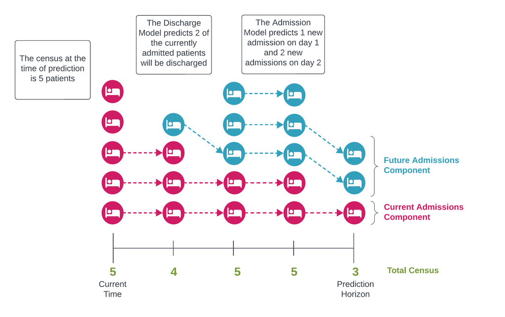

**Load census, admissions, and scheduled admissions data**

```r
train_test_split_date <- as_date("2022-09-30")

census_data <- readRDS("manuscript/data/census.rds")
admission_data <- readRDS("manuscript/data/admissions.rds")
scheduled_admissions <- readRDS("manuscript/data/scheduled_admissions.rds") |>
  count(transplant_type, date, admission_date, name = "scheduled")
```

**Plot representative example of census components **(Figure 2)**

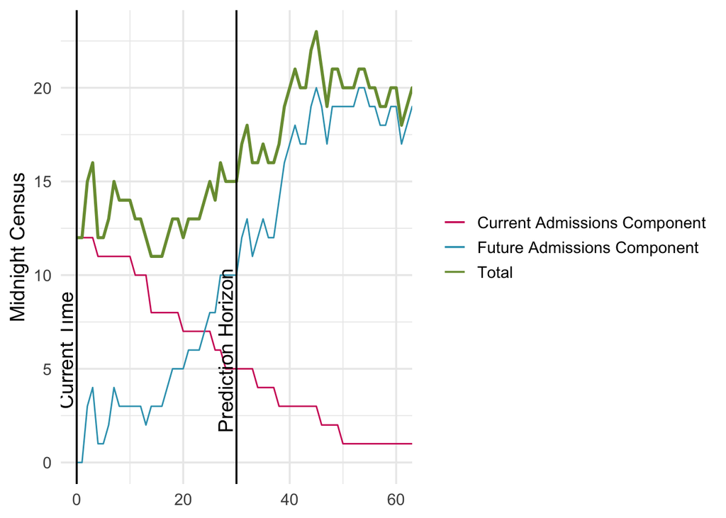

```r
# Date when the data was refreshed
censoring_date <- as_date("2024-2-29")

manuscript_census_data <- census_data |>
  mutate(
    admission_type = case_match(
      transplant_type,
      "Allogeneic" ~ "Allo HSCT",
      "Autologous" ~ "Auto HSCT",
      "No Transplant" ~ "Other"
    ),
    admission_type = factor(admission_type, levels = c("Auto HSCT", "Allo HSCT", "Other"), ordered = TRUE),
    admission_type_malig = case_when(
      admission_type == "Allo HSCT" & malignant == "Yes" ~ "Allo HSCT (Malignant)",
      admission_type == "Allo HSCT" & malignant == "No" ~ "Allo HSCT (Non-Malignant)",
      .default = admission_type
    ),
    admission_type_malig = factor(admission_type_malig, levels = c("Auto HSCT", "Allo HSCT (Malignant)", "Allo HSCT (Non-Malignant)", "Other"), ordered = TRUE)
  )

fig_2 <- list()

fig_2$date <- as_date("2023-04-01")
fig_2$h <- 65

fig_2$base_data <- manuscript_census_data |>
  filter(time > 0, date == fig_2$date)

fig_2$current_admit_data <- fig_2$base_data |>
  extend_discharge_data(fig_2$h, end_var = bmt_team_end_date) |>
  mutate(date = fig_2$date + .h) |>
  summarize(value = sum(discharge == "No"), .by = date)

# Add in time 0 row
fig_2$current_admit_data <- bind_rows(
  count(fig_2$base_data, date, name = "value"),
  fig_2$current_admit_data
)

fig_2$new_admit_data <- admission_data |>
  filter(date == fig_2$date) |>
  unnest(census_contribution) |>
  filter(h <= fig_2$h) |>
  mutate(date = date + h) |>
  summarize(value = sum(actual), .by = date)

# Add in time 0 row
fig_2$new_admit_data <- bind_rows(
  tibble(date = fig_2$date, value = 0),
  fig_2$new_admit_data
)

fig_2$data <- inner_join(
  rename(fig_2$current_admit_data, current = value),
  rename(fig_2$new_admit_data, new = value),
  by = "date",
  relationship = "one-to-one",
  unmatched = "error"
) |>
  mutate(total = current + new, x = row_number() - 1) |>
  select(-date)

fig_2$text_y <- 6

components <- list()
components$names <- c("current", "new", "total")
components$labs <- c("Current Admissions Component", "Future Admissions Component", "Total")
components$colors <- chop_colors(c("pink", "blue", "green"))

levels <- components$names |>
  set_names(components$labs)

colors <- components$colors |>
  set_names(components$labs)

fig_2$data |>
  pivot_longer(-x) |>
  mutate(name = fct_recode(
    factor(name, components$names),
    !!!levels
  )) |>
  ggplot(aes(x = x, y = value, color = name)) +
  geom_line(aes(linewidth = name)) +
  geom_vline(xintercept = c(0, 30)) +
  annotate("text",
    y = fig_2$text_y,
    x = 30,
    label = "Prediction Horizon",
    angle = 90,
    vjust = -.25
  ) +
  annotate("text",
    y = fig_2$text_y,
    x = 0,
    label = "Current Time",
    angle = 90,
    vjust = -.25
  ) +
  labs(
    color = NULL,
    y = "Midnight Census",
    x = NULL
  ) +
  coord_cartesian(xlim = c(as_date(NA), fig_2$h - 5)) +
  scale_linewidth_manual(values = c(Total = 1), na.value = .5, guide = "none") +
  scale_color_manual(values = colors) +
  theme_minimal(base_size = 14)
```

**Plot length of stay by admission type **(Figure 3a)**

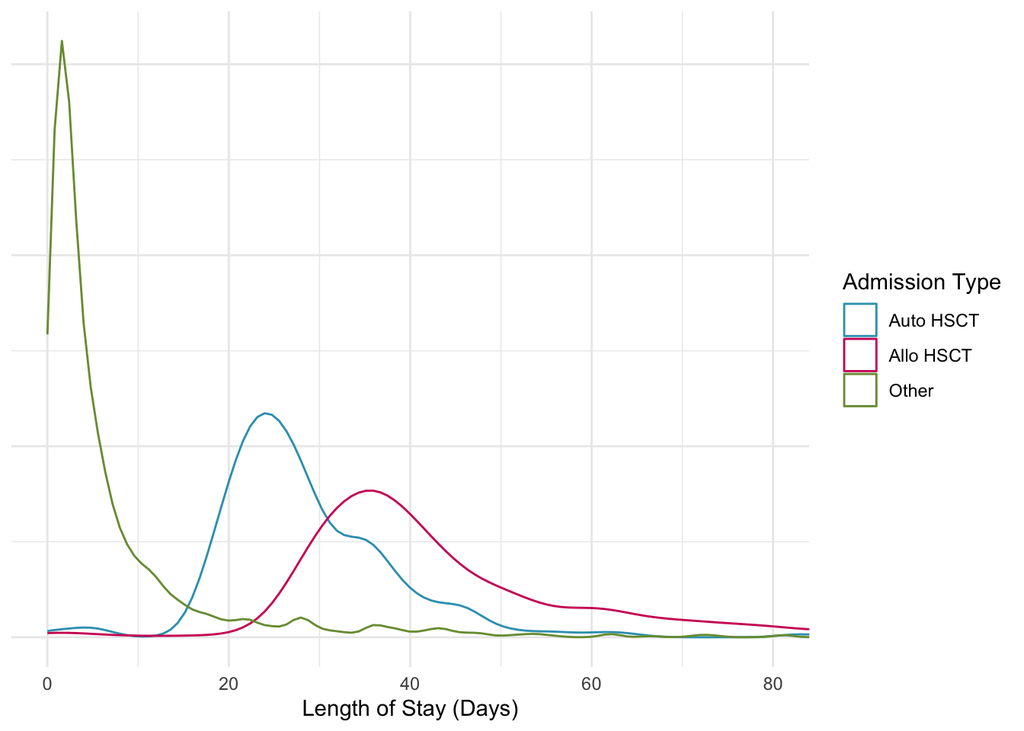

```r
manuscript_encounter_data <- manuscript_census_data |>
  filter(bmt_team_start_date >= "2016-01-01") |>
  distinct(csn, bmt_team_start_date, bmt_team_end_date, admission_type, malignant, malignancy_history, admission_type_malig) |>
  mutate(
    censored = is.na(bmt_team_end_date),
    los = as.numeric(coalesce(bmt_team_end_date, censoring_date) - bmt_team_start_date, unit = "days")
  )

manuscript_encounter_data |>
  ggplot(aes(x = los, color = admission_type)) +
  geom_density() +
  coord_cartesian(xlim = c(0, 80)) +
  labs(
    x = "Length of Stay (Days)",
    y = NULL,
    color = "Admission Type"
  ) +
  theme(axis.text.y = element_blank()) +
  scale_color_chop()
```

**Plot daily census by admission type **(Figure 3b)**

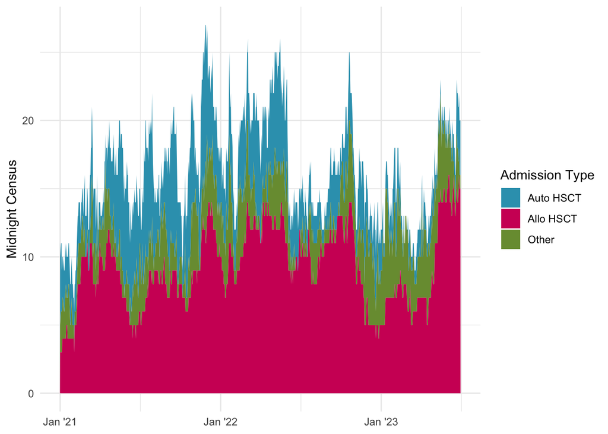

```r
fig_3b_data <- manuscript_census_data |>
  filter(time > 0, date >= "2021-01-01") |>
  count(date, admission_type, name = "value") |>
  complete(
    date = seq(as_date("2021-01-01"), as_date("2023-06-30"), by = "day"),
    admission_type,
    fill = list(value = 0)
  )

fig_3b_data |>
  ggplot(aes(x = date, y = value, fill = admission_type)) +
  geom_area(aes(group = fct_relevel(admission_type, "Allo HSCT", after = Inf))) +
  labs(
    fill = "Admission Type",
    y = "Midnight Census",
    x = NULL
  ) +
  scale_fill_chop() +
  scale_x_date(date_labels = "%b '%y")
```

**Generate admission counts by year and admission type **(Table 1)**

```r
table_1 <- list()

table_1$by_type <- manuscript_encounter_data |>
  mutate(year = year(bmt_team_start_date)) |>
  filter(year < 2023) |>
  count(year, admission_type_malig) |>
  pivot_wider(names_from = year, values_from = n)

table_1$total <- table_1$by_type |>
  summarize(
    admission_type_malig = "Total",
    across(-admission_type_malig, sum)
  )

bind_rows(table_1) |>
  rename(`Admission Type` = admission_type_malig) |>
  kbl() |>
  add_header_above(c(" ", "Number of Admissions (Calendar Year)" = ncol(table_1$total) - 1), bold = TRUE)
```

| Admission Type | Number of Admissions (Calendar Year) 2016 | Number of Admissions (Calendar Year) 2017 | Number of Admissions (Calendar Year) 2018 | Number of Admissions (Calendar Year) 2019 | Number of Admissions (Calendar Year) 2020 | Number of Admissions (Calendar Year) 2021 | Number of Admissions (Calendar Year) 2022 |
| --- | --- | --- | --- | --- | --- | --- | --- |
| Auto HSCT | 48 | 65 | 47 | 67 | 63 | 91 | 68 |
| Allo HSCT (Malignant) | 62 | 48 | 51 | 47 | 59 | 56 | 60 |
| Allo HSCT (Non-Malignant) | 21 | 32 | 38 | 29 | 29 | 34 | 38 |
| Other | 207 | 212 | 212 | 174 | 145 | 161 | 126 |
| Total | 338 | 357 | 348 | 317 | 296 | 342 | 292 |

**Generate descriptive statistics of LOS and admission rates **(Table 2)**

```r
table_2 <- list()

table_2$los_data <- manuscript_encounter_data |>
  summarize(
    median = median(los),
    q1 = quantile(los, probs = .25),
    q3 = quantile(los, probs = .75),
    .by = admission_type_malig
  )

table_2$census_share_data <- manuscript_census_data |>
  filter(time > 0, date >= "2016-01-01") |>
  count(date, admission_type_malig, name = "value") |>
  complete(
    date = seq(as_date("2016-01-01"), as_date("2023-06-30"), by = "day"),
    admission_type_malig,
    fill = list(value = 0)
  ) |>
  mutate(pct = value / sum(value), .by = date) |>
  summarize(pct = mean(pct), .by = admission_type_malig)

table_2$census_share_data |>
  arrange(admission_type_malig) |>
  left_join(table_2$los_data, by = "admission_type_malig") |>
  mutate(
    across(c(median, q1, q3), \(x) round(x, 1)),
    q1_q3 = paste(q1, q3, sep = ", "),
    pct = paste0(round(pct*100, 1), "%")
  ) |>
  select(
    `Admission Type` = admission_type_malig,
    `Average % of Census` = pct,
    `Median LOS (Days)` = median,
    `LOS Q1, Q3 (Days)` = q1_q3
  )
```

| Admission Type | Average % of Census | Median LOS (Days) | LOS Q1, Q3 (Days) |
| --- | --- | --- | --- |
| Auto HSCT | 21.4% | 26.7 | 22.7, 34 |
| Allo HSCT (Malignant) | 25.3% | 40.9 | 35.1, 54 |
| Allo HSCT (Non-Malignant) | 29% | 37.1 | 31.3, 52.1 |
| Other | 24.3% | 3.0 | 1.5, 7.6 |

## Model Selection

**Split census data into train and test set**

Patients may have multiple encounters. In order to prevent leakage between training and testing we remove patients from the training data that appear in the test set.

```r
census_data_split <- census_data |>
  # Don't need these extra columns
  select(!any_of(c("admission_type", "admit_sched_date"))) |>
  train_test_split(split_date = train_test_split_date)
```

**Split admission data into train and test set**

```r
test_length <- as.numeric(max(admission_data$date) - train_test_split_date, unit = "days")

admissions_ts_split <- admission_data |>
  time_series_split(
    date_var = date,
    assess = test_length,
    cumulative = TRUE
  )
```

```r
discharge_train <- training(census_data_split)
admission_train <- training(admissions_ts_split)

discharge_test <- testing(census_data_split)
admission_test <- testing(admissions_ts_split)

save_data(census_data_split, "manuscript/data-split/census.rds")
save_data(admissions_ts_split, "manuscript/data-split/admissions.rds")
```

**Define candidates for discharge and admission models**

The discharge model is a binary classification model predicting discharge on a given day.

The admission model is a count model predicting the number of new admissions per day by `transplant_type`.

Discharge: - Logistic Regression - XGBoost

Admission: - Poisson Regression - XGBoost

```r
discharge_models <- list(
  logistic = logistic_reg(),
  xgboost = boost_tree(mode = "classification")
)

discharge_wflowset <- workflow_set(
  preproc = list(baseline = discharge_rec(discharge_train)),
  models = discharge_models
)

admission_wflow_poisson <- workflow(
  preprocessor = admission_rec(admission_train, type = "poisson"),
  spec = poisson_reg("regression")
)

admission_wflow_xgb <- workflow(
  preprocessor = admission_rec(admission_train, type = "xgb"),
  spec = boost_tree("regression") |>
    set_engine("xgboost", objective = "count:poisson")
)

admission_model_tbl <- modeltime_table(
  fit(admission_wflow_poisson, admission_train),
  fit(admission_wflow_xgb, admission_train)
)

admission_model_tbl$.model_id <- c("poisson", "xgboost")
```

**Create folds for cross-validation**

A single fold consists of a discharge fold and an admission fold aligned by prediction date, the first date in the test split of the fold.

Each discharge fold contains:

- A test split with the census on the prediction date
- A train split with the census for all days before the prediction date

Each admission fold contains:

- A test split with admissions data for the prediction date and the 90 days after
- A train split admission data for all days before the prediction date

```r
splits <- make_cv_splits(
  discharge_train,
  admission_train,
  h = 90,
  scheduled_admissions = scheduled_admissions
)
```

**Run cross-validation to compare candidate models**

```r
discharge_results_cv <- fit_discharge_resamples(discharge_wflowset, splits)

admission_results_cv <- fit_admission_resamples(admission_model_tbl, splits$admission)

cv_results <- collect_cv_results(admission_results_cv, discharge_results_cv, splits)

save_data(cv_results, "manuscript/results/cv_results.rds")
```

**Compute RMSE for model selection results**

```r
cv_results_summary <- cv_results |>
  select(admission_model, discharge_model, id, results) |>
  unnest(results) |>
  filter(.h %in% c(15, 30, 60, 90)) |>
  pivot_longer(
    matches("actual|pred"),
    names_to = c(".value", "stat"),
    names_pattern = "\\.(actual|pred)_(.+)"
  ) |>
  group_by(admission_model, discharge_model, stat, .h) |>
  rmse(actual, pred) |>
  filter(stat == "census")
```

**Generate line plot of model RMSE over prediction horizon**

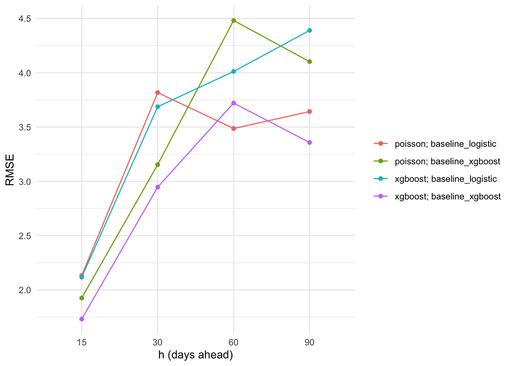

```r
cv_results_summary |>
  ggplot(aes(color = paste(admission_model, discharge_model, sep = "; "), y = .estimate, x = factor(.h))) +
  geom_point() +
  geom_line(aes(group = paste(admission_model, discharge_model))) +
  labs(y = "RMSE", x = "h (days ahead)", color = NULL)
```

## Model Tuning

Having selected the XGBoost model for both the admission and discharge models we now jointly tune all hyperparameters using grid search.

**Create tuning grid for discharge model**

```r
discharge_model_tune <- boost_tree(
  mode = "classification",
  sample_size = tune(),
  learn_rate = tune(),
  trees = 1000,
  min_n = tune(),
  mtry = tune()
)

params <- discharge_model_tune |>
  extract_parameter_set_dials() |>
  finalize(bake(prep(discharge_rec(discharge_train)), new_data = NULL))

discharge_wflowset_tune <- workflow_set(
  preproc = list(baseline = discharge_rec(discharge_train)),
  models = list(xgboost = discharge_model_tune)
) |>
  option_add(grid = 20, param_info = params)
```

**Fit models on discharge tuning grid**

```r
plan("multisession")

discharge_results_tune <- fit_discharge_resamples(discharge_wflowset_tune, splits)

plan("sequential")
```

**Create tuning grid for admission model**

```r
admission_model_tune <- boost_tree(
  mode = "regression",
  trees = 1000,
  sample_size = tune(),
  learn_rate = tune(),
  min_n = tune(),
  mtry = tune()
) |>
  set_engine("xgboost", objective = "count:poisson")

admission_grid <- admission_model_tune |>
  extract_parameter_set_dials() |>
  finalize(juice(prep(admission_rec(admission_train, type = "xgb")))) |>
  grid_space_filling(size = 20)

admission_model_grid <- create_model_grid(
  grid = admission_grid,
  f_model_spec = boost_tree,
  engine_name = "xgboost",
  mode = "regression",
  trees = 1000,
  engine_params = list(objective = "count:poisson")
)
```

**Fit models on admission tuning grid**

```r
plan("multisession")

admission_model_tbl_tune <- workflow_set(
  preproc = list(admission_rec(admission_train, type = "xgb")),
  models = admission_model_grid$.models
) |>
  modeltime_fit_workflowset(data = admission_train, control = control_fit_workflowset(allow_par = TRUE))

admission_model_tbl_tune$.model_id <- "xgboost"
admission_model_tbl_tune$.config <- 1:nrow(admission_model_tbl_tune)
admission_model_tbl_tune$hyperparams <- admission_model_grid |>
  select(-.models) |>
  pmap(tibble)

admission_results_tune <- fit_admission_resamples(admission_model_tbl_tune, splits$admission)

plan("sequential")
```

**Generate results for joint discharge-admission tuning grid**

```r
plan("multisession")

tune_results <- collect_cv_results(admission_results_tune, discharge_results_tune, splits)

plan("sequential")

save_data(tune_results, "manuscript/results/tune_results.rds")
```

**Plot ranked MAPE for top 30 model configuration**

```r
mset <- metric_set(rmse, mape)

tune_results_summary <- tune_results |>
  rename(discharge = discharge_hyperparams, admission = admission_hyperparams) |>
  unnest(c(discharge, admission), names_sep = "_") |>
  unnest(results) |>
  filter(.h %in% c(15, 30, 60, 90)) |>
  pivot_longer(
    matches("actual|pred"),
    names_to = c(".value", "stat"),
    names_pattern = "\\.(actual|pred)_(.+)"
  ) |>
  group_by(admission_config, discharge_config, stat, .h, pick(matches("mtry|min_n|learn_rate|sample_size$"))) |>
  mset(actual, pred) |>
  filter(stat == "census")
```

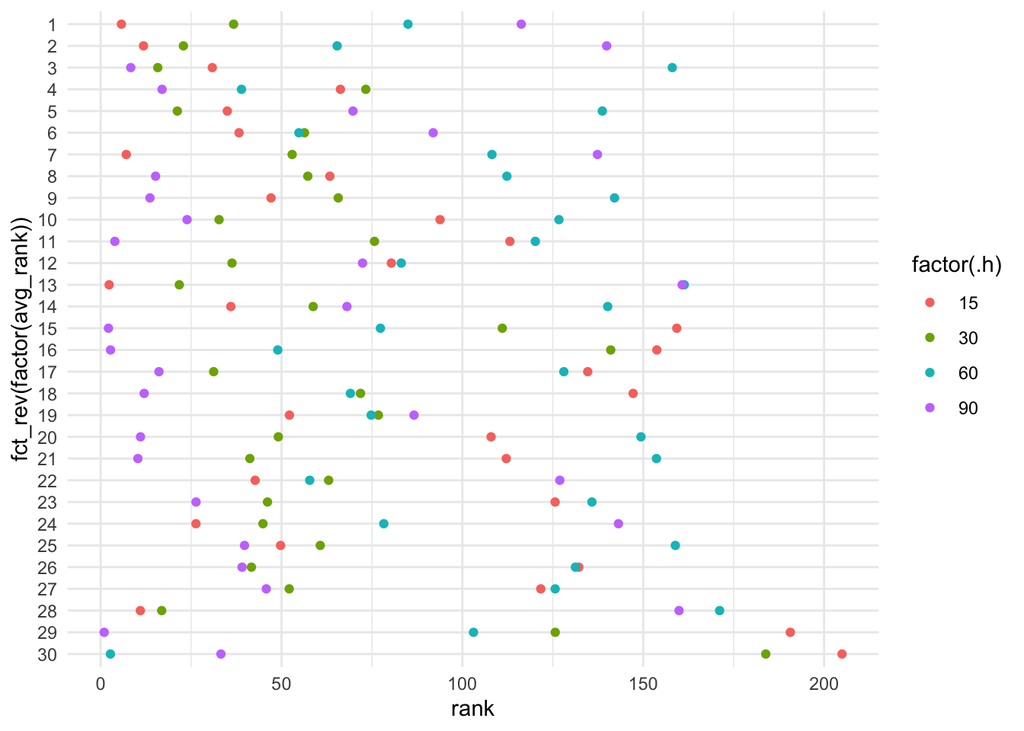

```r
tune_results_summary |>
  filter(.metric == "mape") |>
  mutate(avg_estimate = mean(.estimate), .by = c(admission_config, discharge_config)) |>
  mutate(rank = rank(.estimate), .by = .h) |>
  mutate(avg_rank = dense_rank(avg_estimate)) |>
  filter(avg_rank <= 30) |>
  ggplot(aes(y = fct_rev(factor(avg_rank)), x = rank)) +
  geom_jitter(aes(color = factor(.h)), height = 0)
```

**Plot ranked RMSE for top 30 model configuration**

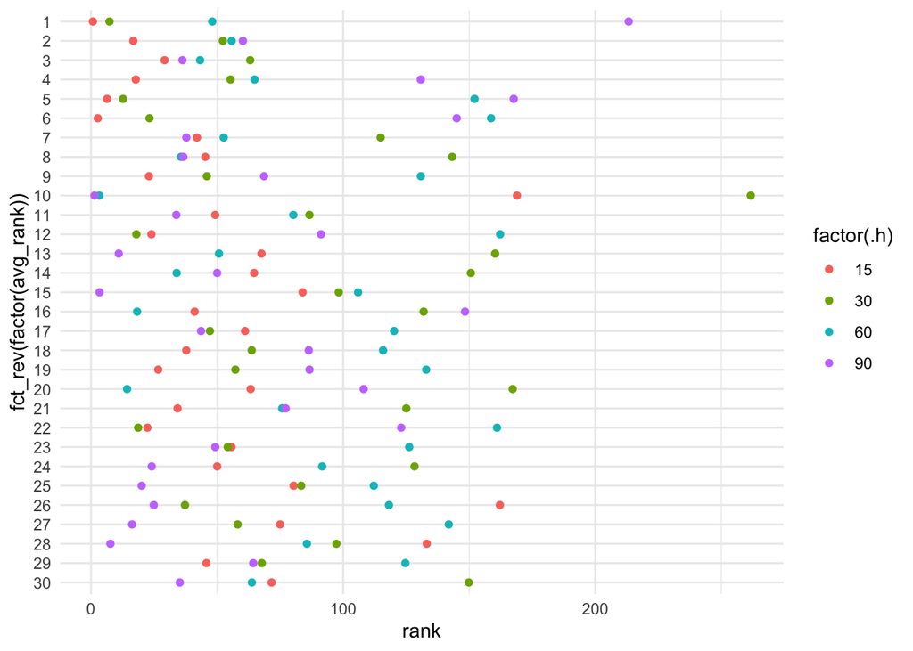

```r
tune_results_summary |>
  filter(.metric == "rmse") |>
  mutate(avg_estimate = mean(.estimate), .by = c(admission_config, discharge_config)) |>
  mutate(rank = rank(.estimate), .by = .h) |>
  mutate(avg_rank = dense_rank(avg_estimate)) |>
  filter(avg_rank <= 30) |>
  ggplot(aes(y = fct_rev(factor(avg_rank)), x = rank)) +
  geom_jitter(aes(color = factor(.h)), height = 0)
```

**Select model with minimal RMSE**

```r
best_config <- tune_results_summary |>
  filter(.metric == "rmse") |>
  mutate(avg_estimate = mean(.estimate), .by = c(admission_config, discharge_config)) |>
  filter(dense_rank(avg_estimate) == 1) |>
  distinct(admission_config, discharge_config)

final_params <- tune_results |>
  filter(
    discharge_config == best_config$discharge_config,
    admission_config == best_config$admission_config
  ) |>
  distinct(admission_hyperparams, discharge_hyperparams) |>
  as.list() |>
  map(pluck(1))

final_params$admission_hyperparams
```

| mtry | min_n | learn_rate | sample_size |
| --- | --- | --- | --- |
| 3 | 9 | 0.0036468 | 0.9712415 |

```r
final_params$discharge_hyperparams
```

| mtry | min_n | learn_rate | sample_size |
| --- | --- | --- | --- |
| 6 | 28 | 0.005141 | 0.1383986 |

## Model Evaluation

**Fit selected model on full training data**

```r
discharge_model_train <- workflow(
  discharge_rec(discharge_train),
  discharge_model_tune
) |>
  finalize_workflow(final_params$discharge_hyperparams) |>
  fit(discharge_train)

admission_model_train <- workflow(
  admission_rec(admission_train, type = "xgb"),
  admission_model_tune
) |>
  finalize_workflow(final_params$admission_hyperparams) |>
  fit(admission_train) |>
  modeltime_table()

models_train <- bmt_model(discharge_model = discharge_model_train, admission_model = admission_model_train)

save_data(models_train, "manuscript/models/models_train.rds")
```

**Predict on held-out test data**

```r
test_dates <- unique(admission_test$date)

test_results <- make_test_data(test_dates, discharge_test, admission_test, scheduled_admissions)

test_results$results <- pmap(test_results, \(current_admissions, scheduled_admissions, ...) {
  predict_census(
    models = models_train,
    h = 1:90,
    current_census = current_admissions,
    scheduled_admissions = scheduled_admissions
  )
})

save_data(test_results, "manuscript/results/test_results.rds")
```

Prospective validation data are the results of an automated process that made daily, prospective predictions of the census.

**Load prospective validation data**

```r
validation_results <- readRDS("manuscript/data/validation_results.rds")

withr::with_seed(71919, {
  validation_results_bootstrap <- validation_results |>
    filter(.h %in% c(15, 30, 60), !is.na(.actual_census)) |>
    generate_bootstraps(bootstrap_block_size = 7)
})
```

**Calculate evaluation metrics for test set and prospective validation **(Table 3)**

```r
manuscript_test_results <- left_join(
  test_results |>
    select(test_date, results) |>
    unnest(results),
  test_results |>
    select(test_date, actual) |>
    unnest(actual),
  by = c("test_date", ".h")
  ) |>
  filter(.h <= 60)

table_3 <- list()

table_3$test <- make_metrics_table(manuscript_test_results) |>
  filter(Component == "Total Census") |>
  select(-Component)

table_3$validation <- make_metrics_table(validation_results) |>
  filter(Component == "Total Census") |>
  select(-Component)

table_3$thresholds <- tibble(
  Horizon = c(15, 30, 60),
  `Prospective Validation MAPE Threshold` = c(15, 20, 25),
  `Prospective Validation Result` = "Pass"
)

validation_estimates <- table_3$validation |>
  rename(.h = Horizon) |>
  pivot_longer(c(RMSE, MAPE), names_to = ".metric") |>
  mutate(.metric = tolower(.metric))

table_3$boot <- summarize_bootstrap(validation_results_bootstrap, validation_estimates)$table_empirical |>
  filter(.metric == "mape") |>
  select(Horizon = .h, `Prospective Validation MAPE 95% Bound` = `0.95`)

left_join(
  rename_with(table_3$test, \(x) paste("Test Set", x), c(RMSE, MAPE)),
  rename_with(table_3$validation, \(x) paste("Prospective Validation", x), c(RMSE, MAPE)),
  by = "Horizon"
) |>
  left_join(table_3$boot, by = "Horizon") |>
  left_join(table_3$thresholds, by = "Horizon") |>
  mutate(
    across(ends_with("RMSE"), \(x) round(x, 1)),
    across(ends_with("MAPE"), \(x) round(x, 1)),
    across(ends_with("MAPE 95% Bound"), \(x) round(x, 1))
  ) |>
  kbl(
    col.names = c(
      "Prediction Horizon (Days)",
      "RMSE",
      "MAPE",
      "RMSE",
      "MAPE",
      "MAPE 95% Upper Bound",
      "MAPE 95% Upper Bound Threshold",
      "Result"
    ),
    align = "c"
  ) |>
  add_header_above(c(" " = 1, "Held-out Test Set" = 2, "Prospective Validation" = 5), bold = TRUE)
```

| Prediction Horizon (Days) | Held-out Test Set RMSE | Held-out Test Set MAPE | Prospective Validation RMSE | Prospective Validation MAPE | Prospective Validation MAPE 95% Upper Bound | Prospective Validation MAPE 95% Upper Bound Threshold | Prospective Validation Result |
| --- | --- | --- | --- | --- | --- | --- | --- |
| 15 | 2.5 | 13.2 | 2.5 | 12.4 | 14.8 | 15 | Pass |
| 30 | 3.1 | 16.4 | 1.7 | 8.1 | 10.3 | 20 | Pass |
| 60 | 3.6 | 18.2 | 2.5 | 11.2 | 12.9 | 25 | Pass |

**Plot total census predictions for the test set **(Figure 4a)**

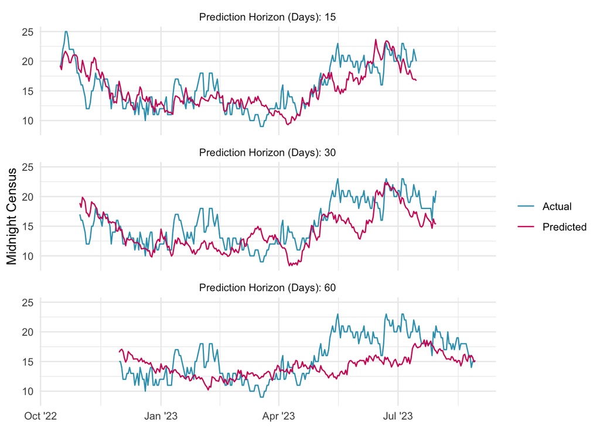

```r
manuscript_test_results |>
  plot_results(.pred_census, .actual_census)
```

**Plot total census predictions for the prospective validation **(Figure 4b)**

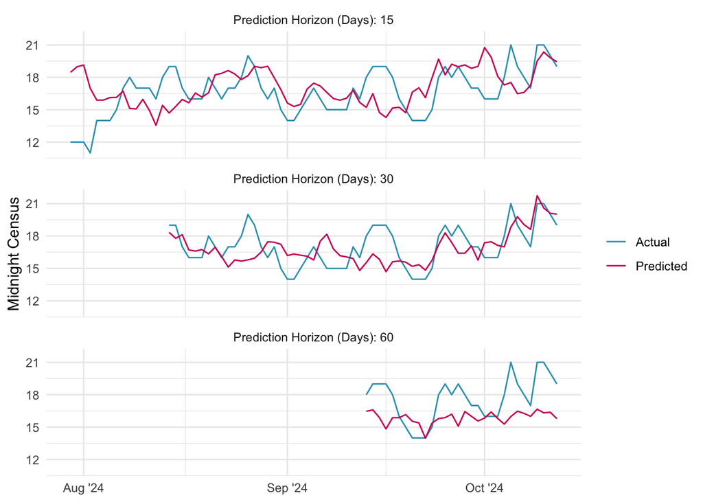

```r
validation_results |>
  plot_results(.pred_census, .actual_census) +
  scale_y_continuous(breaks = c(12, 15, 18, 21))
```

**Plot sample prediction curves for current admissions component on the test set **(Figure S1a)**

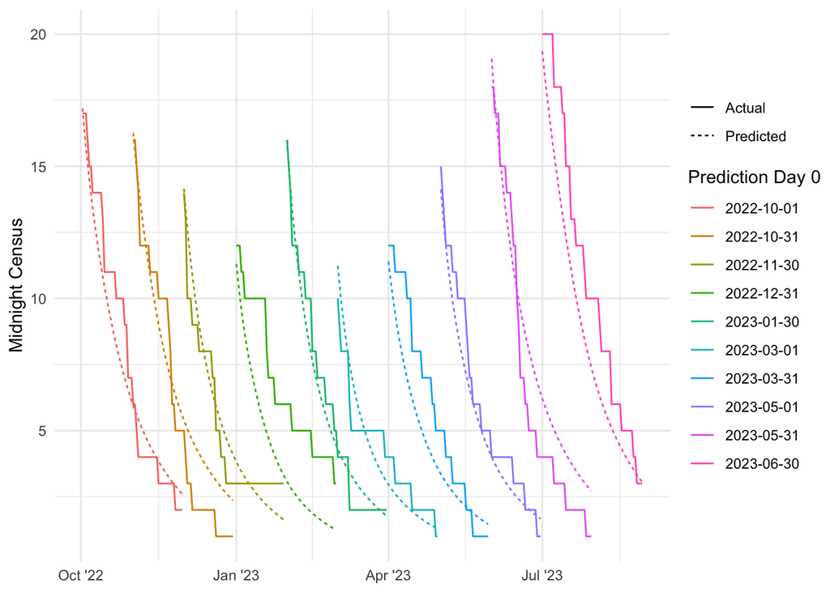

```r
manuscript_test_results |>
  plot_prediction_curves(
    pred = .pred_current_admission,
    actual = .actual_current_admission,
    group = test_date,
    n_show = 10
  )
```

**Plot sample prediction curves for current admissions component on the prospective validation **(Figure S1b)**

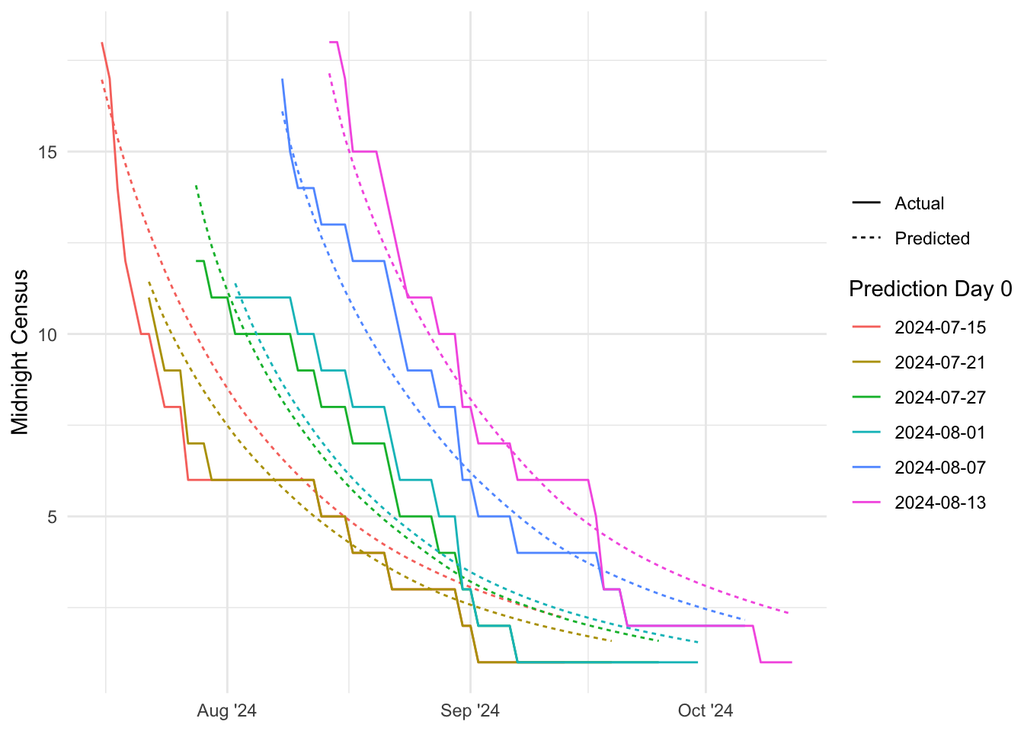

```r
validation_results |>
  filter(max(.h) == 60, .by = prediction_date) |>
  plot_prediction_curves(
    pred = .pred_current_admission,
    actual = .actual_current_admission,
    group = prediction_date,
    n_show = 6
  )
```

**Plot sample prediction curves for future admissions component on the test set **(Figure S2a)**

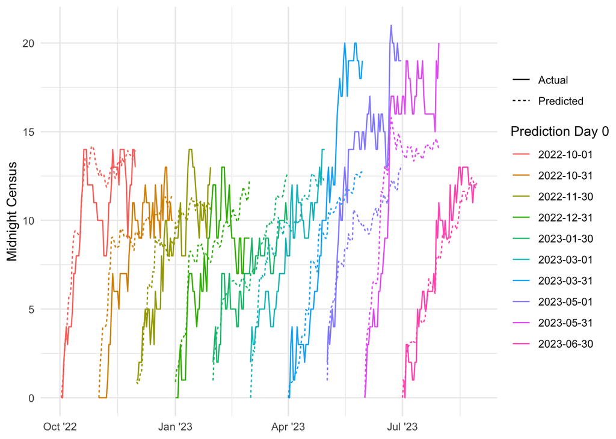

```r
manuscript_test_results |>
  plot_prediction_curves(
    pred = .pred_new_admission,
    actual = .actual_new_admission,
    group = test_date,
    n_show = 10
  )
```

**Plot sample prediction curves for future admissions component on the prospective validation **(Figure S2b)**

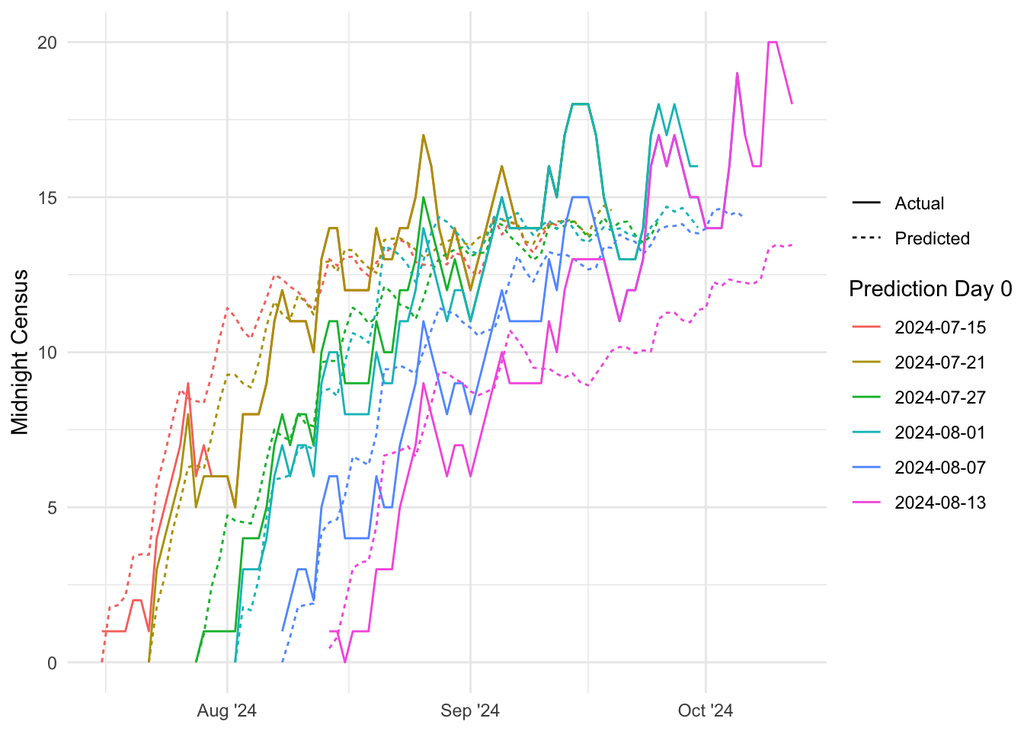

```r
validation_results |>
  filter(max(.h) == 60, .by = prediction_date) |>
  plot_prediction_curves(
    pred = .pred_new_admission,
    actual = .actual_new_admission,
    group = prediction_date,
    n_show = 6
  )
```

**Fit model on full dataset**

```r
discharge_model_final <- fit(models_train$discharge, census_data)

admission_model_final <- modeltime_refit(models_train$admission, admission_data)

models_final <- bmt_model(discharge_model = discharge_model_final, admission_model = admission_model_final)

save_data(models_final, "manuscript/models/models_final.rds")
```

## Supplementary Analyses

**Create total census time series**

```r
census_ts_data <- census_data |>
  filter(time > 0, date >= "2016-01-01") |>
  count(date, name = "value")

census_ts_split <- census_ts_data |>
  time_series_split(
    date_var = date,
    assess = test_length,
    cumulative = TRUE
  )

census_ts_train <- training(census_ts_split)

reframe(census_ts_train, range(date))
```

| range(date) |
| --- |
| 2016-01-01 |
| 2022-09-30 |

```r
census_ts_test <- testing(census_ts_split)

reframe(census_ts_test, range(date))
```

| range(date) |
| --- |
| 2022-10-01 |
| 2023-06-30 |

**Predict test set using heuristic models**

```r
post_process_naive_results <- function(results, h) {
  out <- select(results, .model_desc)

  out$preds <- results$.resample_results |>
    map(\(x) {
      x |>
        select(id, .predictions) |>
        unnest(.predictions) |>
        mutate(.h = row_number(), .by = id) |>
        slice(h, .by = id)
    })

  out |> unnest(preds)
}

# Include prior year of data for seasonal naive model
census_ts_test_leadin <- bind_rows(
  census_ts_train |>
    filter(date > train_test_split_date - 365),
  census_ts_test
)

naive_models <- modeltime_table(
  naive_reg() |>
    set_engine("naive") |>
    fit(value ~ date, census_ts_train),
  naive_reg(seasonal_period = 12) |>
    set_engine("snaive") |>
    fit(value ~ date, census_ts_train)
)

census_ts_test_leadin_split <- time_series_cv(
  census_ts_test_leadin,
  date_var = date,
  assess = "60 days",
  initial = 365,
  cumulative = TRUE
)

naive_results <- naive_models |>
  modeltime_fit_resamples(census_ts_test_leadin_split) |>
  post_process_naive_results(h = c(15, 30, 60))

mean_results <- tibble(
  id = census_ts_test_leadin_split$id,
  .pred = map_dbl(census_ts_test_leadin_split$splits, \(x) mean(training(x)$value))
)

heuristic_results <- bind_rows(
  naive_results,
  naive_results |>
    select(-.pred) |>
    mutate(.model_desc = "MEAN") |>
    left_join(mean_results, by = "id", relationship = "many-to-one", unmatched = "error")
)

save_data(heuristic_results, "manuscript/results/heuristic_results.rds")
```

**Fit simple time series models**

```r
ts_wflow_poisson <- workflow(
  preprocessor = admission_rec(census_ts_train, type = "poisson"),
  spec = poisson_reg("regression")
)

ts_wflow_xgb <- workflow(
  preprocessor = admission_rec(census_ts_train, type = "xgb"),
  spec = boost_tree(
    "regression",
    trees = 1000
  ) |>
    set_engine("xgboost", objective = "count:poisson")
)

ts_models <- modeltime_table(
  fit(ts_wflow_poisson, census_ts_train),
  fit(ts_wflow_xgb, census_ts_train)
) |>
  update_modeltime_description(1, "poisson") |>
  update_modeltime_description(2, "xgboost")
```

**Create tuning grid for simple time series models**

```r
ts_xgb_tune_split <- make_census_ts_splits(census_ts_train, 60, slice_limit = 15, skip = "3 months")

ts_xgb_tune <- boost_tree(
  mode = "regression",
  trees = 1000,
  sample_size = tune(),
  learn_rate = tune(),
  min_n = tune(),
  mtry = tune()
) |>
  set_engine("xgboost", objective = "count:poisson")

ts_xgb_grid <- ts_xgb_tune |>
  extract_parameter_set_dials() |>
  update(learn_rate = learn_rate(range = c(-2.3, -1.6))) |>
  finalize(juice(prep(admission_rec(census_ts_train, type = "xgb")))) |>
  grid_space_filling(size = 20)

ts_xgb_model_grid <- create_model_grid(
  grid = ts_xgb_grid,
  f_model_spec = boost_tree,
  engine_name = "xgboost",
  mode = "regression",
  trees = 1000,
  engine_params = list(objective = "count:poisson")
)
```

**Fit models on time series tuning grid**

```r
plan("multisession")

ts_xgb_model_tbl_tune <- workflow_set(
  preproc = list(admission_rec(census_ts_train, type = "xgb")),
  models = ts_xgb_model_grid$.models
) |>
  modeltime_fit_workflowset(data = census_ts_train, control = control_fit_workflowset(allow_par = TRUE))

ts_xgb_model_tbl_tune$.config <- 1:nrow(ts_xgb_model_tbl_tune)
ts_xgb_model_tbl_tune$hyperparams <- ts_xgb_model_grid |>
  select(-.models) |>
  pmap(tibble)

ts_tune_results <- modeltime_fit_resamples(
  ts_xgb_model_tbl_tune,
  resamples = ts_xgb_tune_split
) |>
  postprocess_ts_resamples(pred_name = ".pred")

plan("sequential")

save_data(ts_tune_results, "manuscript/results/ts_tune_results.rds")
```

**Plot RMSE and MAPE for all configurations in tuning grid**

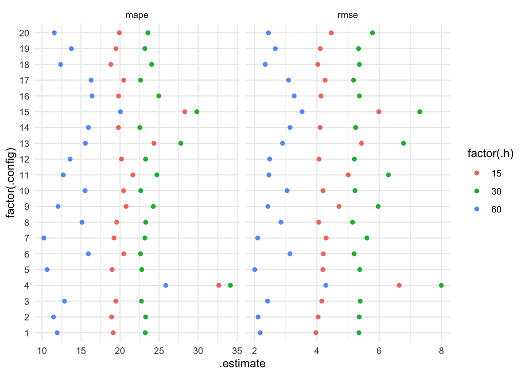

```r
ts_tune_results_summary <- ts_tune_results |>
  unnest(hyperparams) |>
  unnest(results) |>
  filter(.h %in% c(15, 30, 60)) |>
  group_by(.model_id, .h, .config, pick(matches("mtry|min_n|learn_rate|sample_size$"))) |>
  mset(value, .pred)

ts_tune_results_summary |>
  ggplot(aes(x = .estimate, y = factor(.config), color = factor(.h))) +
  geom_point() +
  facet_wrap(~.metric, scales = "free_x")
```

**Select time series model with minimal RMSE**

```r
ts_best_config <- ts_tune_results_summary |>
  filter(.metric == "rmse") |>
  mutate(avg_estimate = mean(.estimate), .by = .config) |>
  filter(dense_rank(avg_estimate) == 1) |>
  distinct(.config)

ts_final_params <- ts_tune_results |>
  filter(
    .config == ts_best_config$.config
  ) |>
  distinct(hyperparams) |>
  pull(hyperparams) |>
  pluck(1)

ts_final_params
```

| mtry | min_n | learn_rate | sample_size |
| --- | --- | --- | --- |
| 1 | 14 | 0.0164357 | 0.4315789 |

```r
ts_xgb_tuned <- workflow(
  admission_rec(census_ts_train, type = "xgb"),
  ts_xgb_tune
) |>
  finalize_workflow(ts_final_params) |>
  fit(census_ts_train) |>
  modeltime_table()
```

**Predict on test set with all time series models**

```r
# Add tuned xgb to models
ts_models <- combine_modeltime_tables(
  ts_models,
  ts_xgb_tuned
) |>
  update_modeltime_description(3, "xgboost tuned")

forecast_test_date <- function(test_date, test_data, models, h = 1:60) {
  max_h <- max(h)
  new_data <- tibble(
    date = seq(test_date, test_date + max_h - 1, by = "day"),
    .h = 1:max_h
  ) |>
    left_join(test_data, by = "date")

  models |>
    modeltime_calibrate(new_data = new_data) |>
    modeltime_forecast(
      new_data,
      keep_data = TRUE
    ) |>
      filter(.h %in% h) |>
      select(all_of(colnames(new_data)), .value, .model_id, .model_desc)
}

# Sample 40 test dates for prediction
ts_test_dates <- census_ts_test |>
  filter(!is.na(lead(value, 60))) |>
  pull(date) |>
  unique() |>
  sample(40)

ts_test_results <- tibble(test_date = ts_test_dates)

ts_test_results$results <- map(
  ts_test_results$test_date,
  forecast_test_date,
  test_data = census_ts_test,
  models = ts_models
)

saveRDS(ts_test_results, "manuscript/results/ts_test_results.rds")
```

**Create summary metrics table for heuristic and time series models **(Table S1)**

```r
heuristic_results_summary <- heuristic_results |>
  group_by(.model_desc, .h) |>
  mset(value, .pred)

ts_results_summary <- ts_test_results |>
  unnest(results) |>
  filter(.h %in% c(15, 30, 60), !is.na(value)) |>
  group_by(.model_desc, .h) |>
  mset(value, .value)

bind_rows(
  heuristic_results_summary,
  ts_results_summary |>
    filter(.model_desc %in% c("poisson", "xgboost tuned")),
  table_3$test |>
    select(.h = Horizon, mape = MAPE, rmse = RMSE) |>
    pivot_longer(c(mape, rmse), names_to = ".metric", values_to = ".estimate") |>
    mutate(.model_desc = "Preferred")
) |>
  mutate(
    .model_desc = case_match(
      .model_desc,
      "MEAN" ~ "Mean",
      "SNAIVE [12]" ~ "Seasonal Naive",
      "NAIVE" ~ "Naive",
      "poisson" ~ "Poisson",
      "xgboost tuned" ~ "GBDT",
      .default = .model_desc
    ),
    model_type = case_match(
      .model_desc,
      c("Mean", "Seasonal Naive", "Naive") ~ "Heuristic Model",
      c("Poisson", "GBDT") ~ "Time Series Model",
      "Preferred" ~ "Component-based Model"
    ),
    .estimate = round(.estimate, 1)
  ) |>
  pivot_wider(id_cols = c(.h, model_type, .model_desc), names_from = .metric, values_from = .estimate) |>
  kbl(
    col.names = c(
    "Prediction Horizon (Days)",
    "Model Type",
    "Model",
    "RMSE",
    "MAPE"
  ),
    align = "c"
  ) |>
  row_spec(16:18, bold = TRUE)
```

| Prediction Horizon (Days) | Model Type | Model | RMSE | MAPE |
| --- | --- | --- | --- | --- |
| 15 | Heuristic Model | Mean | 4.4 | 30.9 |
| 30 | Heuristic Model | Mean | 4.5 | 31.6 |
| 60 | Heuristic Model | Mean | 4.6 | 31.9 |
| 15 | Heuristic Model | Naive | 3.6 | 19.7 |
| 30 | Heuristic Model | Naive | 4.3 | 24.6 |
| 60 | Heuristic Model | Naive | 5.6 | 30.6 |
| 15 | Heuristic Model | Seasonal Naive | 4.0 | 21.9 |
| 30 | Heuristic Model | Seasonal Naive | 4.6 | 27.1 |
| 60 | Heuristic Model | Seasonal Naive | 5.6 | 30.6 |
| 15 | Time Series Model | Poisson | 3.1 | 20.9 |
| 30 | Time Series Model | Poisson | 3.1 | 20.4 |
| 60 | Time Series Model | Poisson | 3.7 | 23.1 |
| 15 | Time Series Model | GBDT | 3.2 | 21.6 |
| 30 | Time Series Model | GBDT | 3.1 | 20.6 |
| 60 | Time Series Model | GBDT | 3.9 | 23.2 |
| 15 | Component-based Model | Preferred | 2.5 | 13.2 |
| 30 | Component-based Model | Preferred | 3.1 | 16.4 |
| 60 | Component-based Model | Preferred | 3.6 | 18.2 |